# Inspiration for ALM assignment

Silas Furu Friby  
2018-04-22

### Pension Company

We consider a pension company with a simplified balance consisting of

*Assets*

- Present value of assets at time \( t \), \( A(t) \) (market value)

*Liabilities*

- Present value of liabilites at time \( t \), \( L(t) \) (market value, different from article)
- Free capital at time \( t \), \( B(t) \)

### Financial market - P-dynamics

\[ \begin{aligned} d\beta(t) &= r(t) \beta(t) dt \\ dr(t) &= \kappa (\theta^P - r(t)) dt + \sigma_r dW^P_1(t) \\ dS(t) &= \mu S(t) dt + \sigma_s S(t) dW^P_3(t) \end{aligned} \]

\( dW^P_3(t) = \rho dW^P_1(t) + \sqrt{1 - \rho ^ 2} dW^P_2(t) \)

### Financial market - Q-dynamics

\[ \begin{aligned} dr(t) &= \kappa (\theta - r(t)) dt + \sigma_r dW_1(t) \\ dS(t) &= r(t) S(t) dt + \sigma_s S(t) dW_3(t) \end{aligned} \]

\( \theta = \theta^P - \frac{\lambda \sigma_r}{\kappa} \)

\( dW_3(t) = \rho dW_1(t) + \sqrt{1 - \rho ^ 2} dW_2(t) \)

### Financial market - ZCB dynamics

P-dynamics

\[ dp(t, T) = p(t, T) (r(t) - \lambda \sigma_r B(t,T)) dt - \sigma_r B(t,T) dW^P_1(t) \]

Q-dynamics

\[ dp(t, T) = p(t, T) r(t) dt - \sigma_r B(t,T) dW_1(t) \]

\( B(t,T) = \frac{1}{\kappa}\left(1 - e^{-\kappa (T - t)} \right) \)

Correlation between stock and interest rate level!

### Financial market - Asset dynamics

Investment in bank, stocks and ZCBs

\[ dA(t) = c_\beta(t) d\beta(t) + c_s(t) dS(t) + \sum_{j = 1}^T c_{ij}(t) dp(t, i + j) \]

for \( t \in [i, i + 1) \).

Note: We need only to simulate under \( P \) in order to obtain \( A(t) \) for \( t \in [0, T] \). Why no need to simulate under \( Q \)?

### Financial market - Liability model

Simple savings contract.

\[ L(T) = premium * (1 + q)^T \]

Where \( premium \) is initial payment and \( q \) is a constant “guaranteed” interest rate.

\[ \begin{aligned} L(t) &= E^Q \left[ e^{\int_t^T r(s) ds} L(T) | \mathcal{F}_t \right] \\ &= E^Q \left[ e^{\int_t^T r(s) ds} | \mathcal{F}_t \right] L(T) \\ &= p(t,T) L(T) \end{aligned} \]

### Simulated asset paths - 100% Stock, dt = 1/12

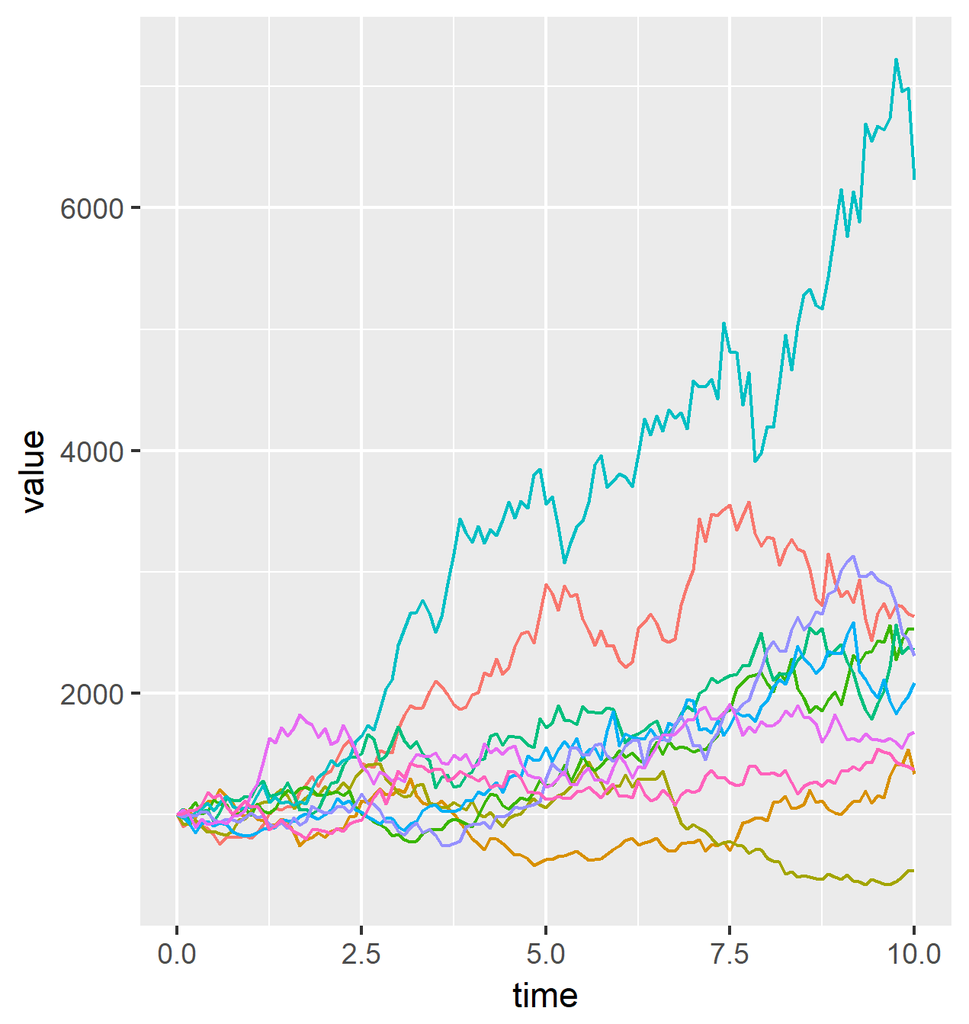

### Simulated asset paths - 100% Bank, dt = 1/12

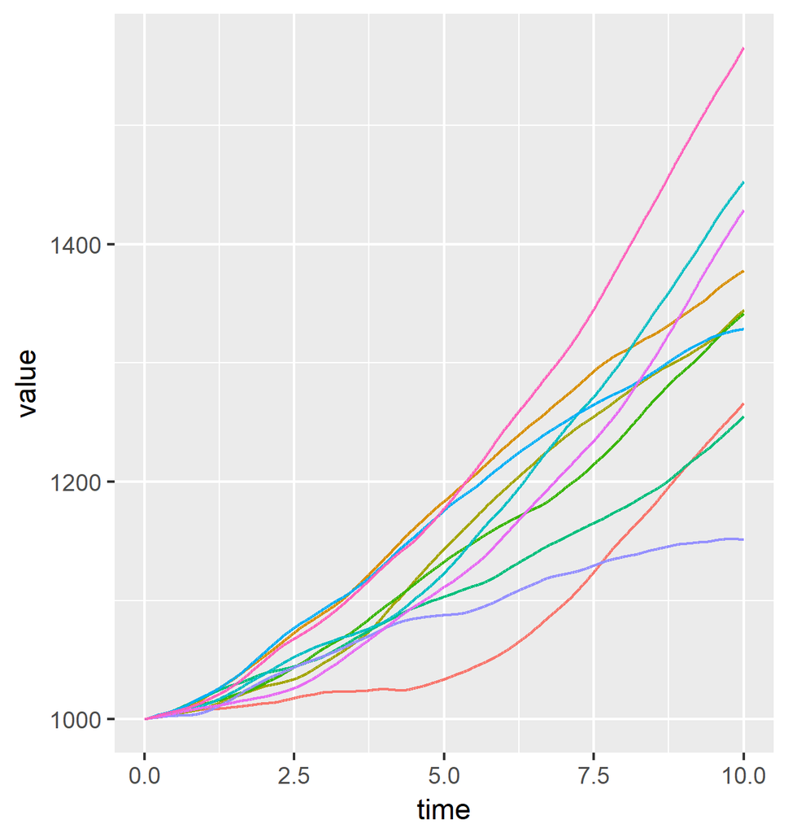

### Simulated asset paths - 100% Bonds, dt = 1/12

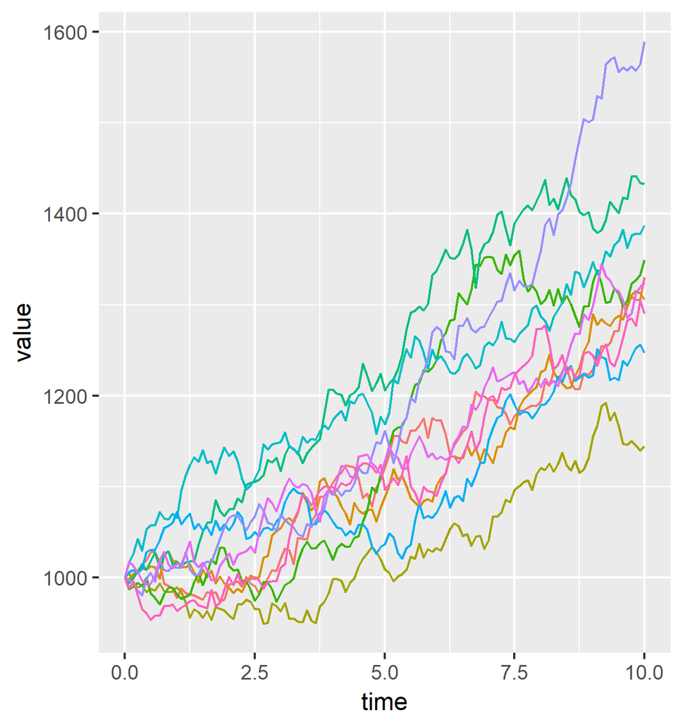

### Asset distribution - 100% Stock, dt = 1/12

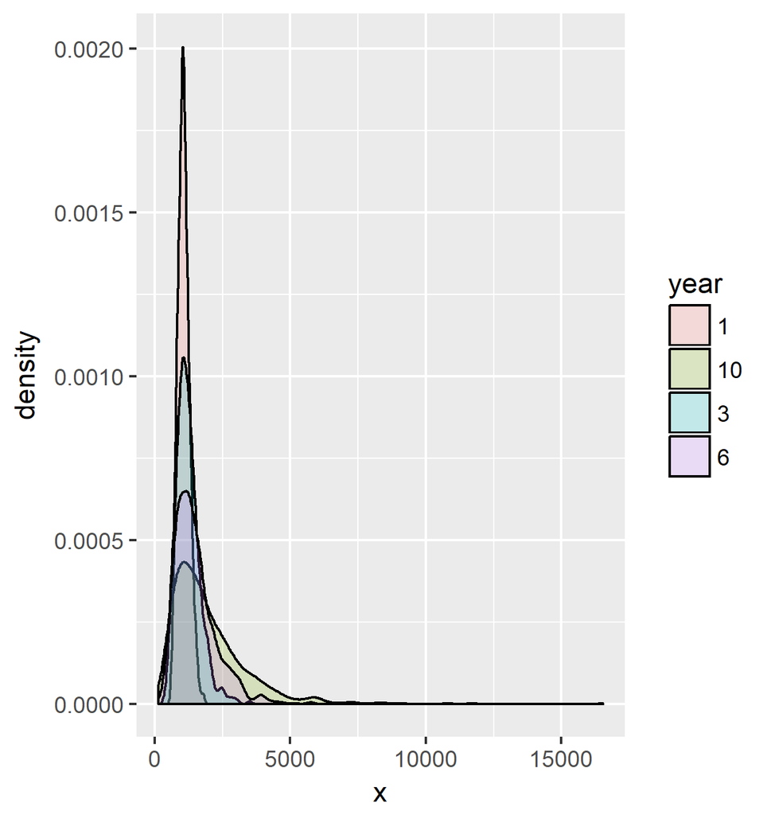

### Asset distribution - 100% Bank, dt = 1/12

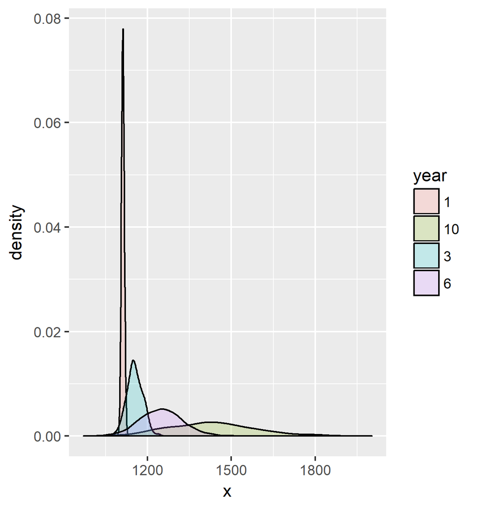

### Asset distribution - 100% Bonds, dt = 1/12

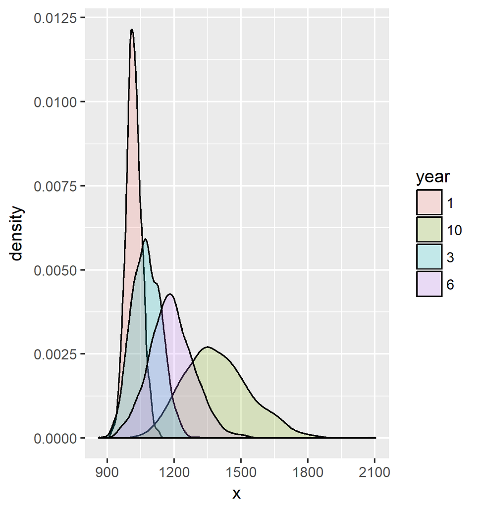

### Remarks on previous plots

Combination of bank, stocks and bonds influence

- Skewness of asset distribution at different times (median vs mean)
- \( P(A(T) < L(T)) \)

Results are very sensitive to changes in model parameters

- given current parameters: approx 10% stocks and 90% to minimize \( P(A(T) < L(T)) \)
- increasing \( \kappa \): approx 100% bank to minimize \( P(A(T) < L(T)) \)

### Asset distribution - Portfolio composition

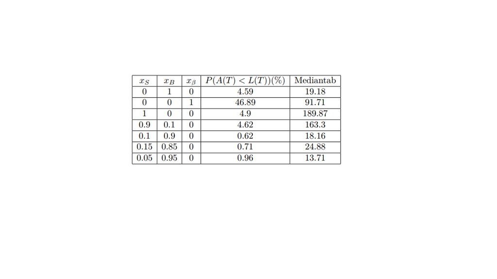

Median loss is the median of the distribution \( (L(T) - A(T)) * 1_{A(T) < L(T)} \)

### Risk management - Solvency 2 and VaR

Solvency 2 SCR = free capital today must insure that risk of default during next year is less than 99.5%

In ohter words, Solvency 2 SCR = 99.5% quantile of 1-year loss distribution

Solvency 2 risk measure: *Value at Risk* (VaR) from *loss* distribution

\[ Loss(t) = B(t) - e^{-\int_t^{t+1} r (s) ds} B(t + 1) \]

\[ CR(t) = \frac{B(t)}{SCR(t)} \]

FSA supervision of company if \( CR \) falls below regulatory level

### Risk management - Example

Initial premium = 1000

“Guaranteed” interest rate = 2.5%

10% stocks 90% bonds

### Risk management - example: free capital, dt = 1/12

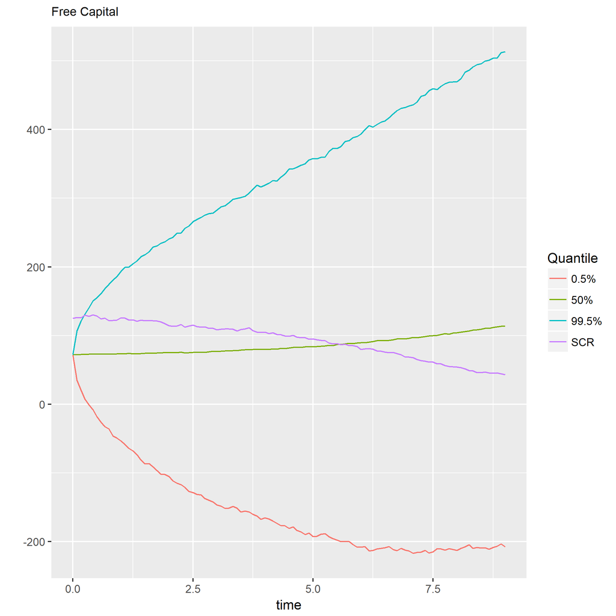

### Risk management - example: CR paths, dt = 1/12

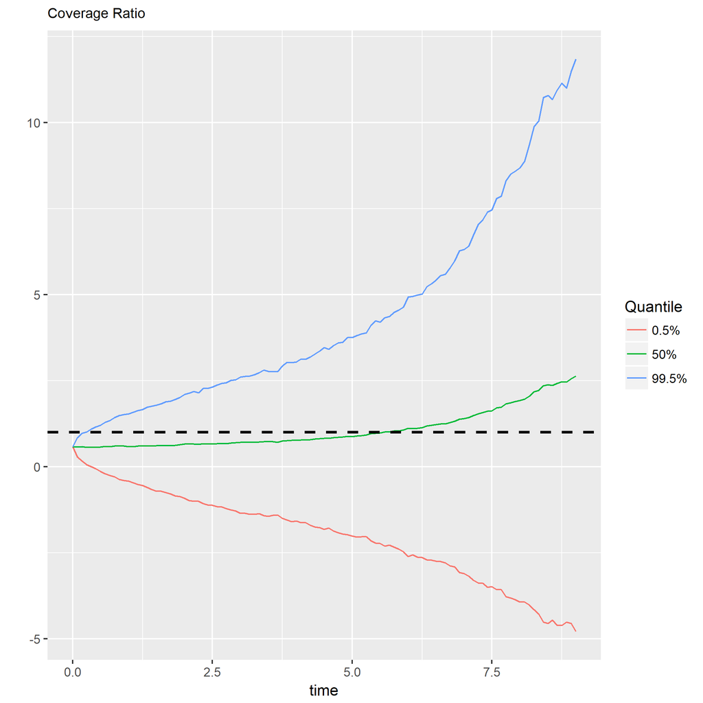

### Risk management - example: insolvency prob, dt = 1/12

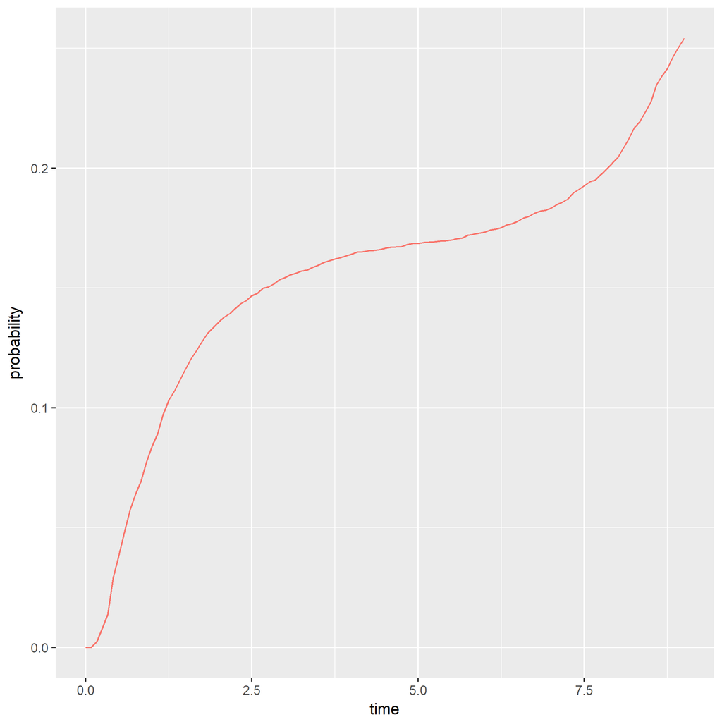

### The End

Thank you!